# TWITTER SENTIMENT ANALYSIS USING ML MODELS

[figure not shown]

# Task 1: Import Libraries

```python
import numpy as np
import pandas as pd
import seaborn as sns
import matplotlib.pyplot as plt
plt.style.use('ggplot')
from sklearn.metrics import roc_curve, auc
from sklearn.metrics import classification_report, confusion_matrix, ConfusionMatrixDisplay
import nltk

from sklearn.model_selection import train_test_split
from mlxtend.plotting import plot_confusion_matrix
import matplotlib.cm as cm
from matplotlib import rcParams
from collections import Counter


import string
from sklearn.model_selection import cross_val_score
from sklearn.metrics import accuracy_score

nltk.download('stopwords')
nltk.download('wordnet')
from nltk.corpus import stopwords
import re
import os
from wordcloud import WordCloud, STOPWORDS
from nltk.stem import WordNetLemmatizer
from nltk.tokenize import word_tokenize
from nltk.stem.porter import PorterStemmer

%matplotlib inline
nltk.download('omw-1.4')
import warnings
warnings.filterwarnings("ignore")
```

# Task 2: Read the Dataset

[figure not shown]

```python
from google.colab import drive
drive.mount('/content/drive')
```

```python
df = pd.read_csv('/content/drive/My Drive/training.1600000.processed.noemoticon.csv',encoding = 'ISO-8859-1', header=None)
```

```python
#df = pd.read_csv('/kaggle/input/sentiment140/training.1600000.processed.noemoticon.csv', encoding = 'ISO-8859-1', header=None)
```

```python
df.head()
```

|  | 0 | 1 | 2 | 3 | 4 | 5 |
| --- | --- | --- | --- | --- | --- | --- |
| 0 | 0 | 1467810369 | Mon Apr 06 22:19:45 PDT 2009 | NO_QUERY | _TheSpecialOne_ | @switchfoot http://twitpic.com/2y1zl - Awww, t... |
| 1 | 0 | 1467810672 | Mon Apr 06 22:19:49 PDT 2009 | NO_QUERY | scotthamilton | is upset that he can't update his Facebook by ... |
| 2 | 0 | 1467810917 | Mon Apr 06 22:19:53 PDT 2009 | NO_QUERY | mattycus | @Kenichan I dived many times for the ball. Man... |
| 3 | 0 | 1467811184 | Mon Apr 06 22:19:57 PDT 2009 | NO_QUERY | ElleCTF | my whole body feels itchy and like its on fire |
| 4 | 0 | 1467811193 | Mon Apr 06 22:19:57 PDT 2009 | NO_QUERY | Karoli | @nationwideclass no, it's not behaving at all.... |

## Renaming the Columns

#### As mentioned in data description, it contains the following 6 fields. Looking at the top part of the dataset we can depioct each column. We can describe them briefly as:

#### 0 - target: the polarity of the tweet (0 = negative, 2 = neutral, 4 = positive)

#### 1 - ids: The id of the tweet ( 2087)

#### 2 - date of the tweet (Sat May 16 23:58:44 UTC 2009)

#### 3 - flag: The query, if there is no query, then this value is NO_QUERY, in each row contains 'NO_QUERY'

#### 4 - the user that tweeted

#### 5 - the text of the tweet

```python
df = df.rename(columns={0: 'target', 1: 'ids', 2: 'date', 3: 'flag', 4: 'username', 5: 'text'})
```

# Task 3: EDA

[figure not shown]

#### *Top five and last five rows of the dataset*

```python
df.head()
```

|  | target | ids | date | flag | username | text |
| --- | --- | --- | --- | --- | --- | --- |
| 0 | 0 | 1467810369 | Mon Apr 06 22:19:45 PDT 2009 | NO_QUERY | _TheSpecialOne_ | @switchfoot http://twitpic.com/2y1zl - Awww, t... |
| 1 | 0 | 1467810672 | Mon Apr 06 22:19:49 PDT 2009 | NO_QUERY | scotthamilton | is upset that he can't update his Facebook by ... |
| 2 | 0 | 1467810917 | Mon Apr 06 22:19:53 PDT 2009 | NO_QUERY | mattycus | @Kenichan I dived many times for the ball. Man... |
| 3 | 0 | 1467811184 | Mon Apr 06 22:19:57 PDT 2009 | NO_QUERY | ElleCTF | my whole body feels itchy and like its on fire |
| 4 | 0 | 1467811193 | Mon Apr 06 22:19:57 PDT 2009 | NO_QUERY | Karoli | @nationwideclass no, it's not behaving at all.... |

```python
df.tail()
```

|  | target | ids | date | flag | username | text |
| --- | --- | --- | --- | --- | --- | --- |
| 1599995 | 4 | 2193601966 | Tue Jun 16 08:40:49 PDT 2009 | NO_QUERY | AmandaMarie1028 | Just woke up. Having no school is the best fee... |
| 1599996 | 4 | 2193601969 | Tue Jun 16 08:40:49 PDT 2009 | NO_QUERY | TheWDBoards | TheWDB.com - Very cool to hear old Walt interv... |
| 1599997 | 4 | 2193601991 | Tue Jun 16 08:40:49 PDT 2009 | NO_QUERY | bpbabe | Are you ready for your MoJo Makeover? Ask me f... |
| 1599998 | 4 | 2193602064 | Tue Jun 16 08:40:49 PDT 2009 | NO_QUERY | tinydiamondz | Happy 38th Birthday to my boo of alll time!!! ... |
| 1599999 | 4 | 2193602129 | Tue Jun 16 08:40:50 PDT 2009 | NO_QUERY | RyanTrevMorris | happy #charitytuesday @theNSPCC @SparksCharity... |

#### *Size of the dataset*

```python
print('size of data is', df.shape)
```

```
size of data is (1600000, 6)
```

#### *Missing values*

```python
df.isnull().sum()
```

```
target      0
ids         0
date        0
flag        0
username    0
text        0
dtype: int64
```

No null values found

#### *Visualization*

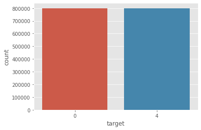

```python
sns.countplot(x='target', data=df)
```

#### There are either 0 or 4 values in target columns

```python
pd.set_option('display.max_colwidth', -1)
```

# 4. Data Preprocessing

[figure not shown]

#### *Checking the text written wrt target cell*

```python
df[df['target']==0]['text'].head()
```

```
0    @switchfoot http://twitpic.com/2y1zl - Awww, that's a bummer.  You shoulda got David Carr of Third Day to do it. ;D
1    is upset that he can't update his Facebook by texting it... and might cry as a result  School today also. Blah!
2    @Kenichan I dived many times for the ball. Managed to save 50%  The rest go out of bounds
3    my whole body feels itchy and like its on fire
4    @nationwideclass no, it's not behaving at all. i'm mad. why am i here? because I can't see you all over there.
Name: text, dtype: object
```

```python
df[df['target']==4]['text'].head()
```

```
800000    I LOVE @Health4UandPets u guys r the best!!
800001    im meeting up with one of my besties tonight! Cant wait!!  - GIRL TALK!!
800002    @DaRealSunisaKim Thanks for the Twitter add, Sunisa! I got to meet you once at a HIN show here in the DC area and you were a sweetheart.
800003    Being sick can be really cheap when it hurts too much to eat real food  Plus, your friends make you soup
800004    @LovesBrooklyn2 he has that effect on everyone
Name: text, dtype: object
```

#### *We can see, 0 has negative texts while 4 has positive texts. Hence, we put positive(4) as 1 and leave negative(0) as it is (0).*

```python
df['target'] = df['target'].replace(4,1)
```

```python
df['target'].value_counts()
```

```
0    800000
1    800000
Name: target, dtype: int64
```

#### *Now we have classes 0 and 1*

#### Let's visualize target column

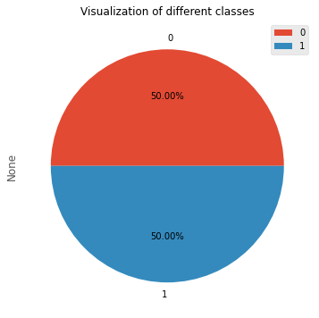

```python
fig = plt.figure(figsize=(12,6))
t = df.groupby('target').size()
t.plot( kind='pie', autopct = "%.2f%%", figsize=(12, 6))
plt.title("Visualization of different classes",fontsize=12)
plt.legend()
plt.show()
```

The datast is perfectly balanced.

### Wordclouds

#### *We can see what words were repeated most often for positive and negative classes.*

As we are showing stopwords so taking base of stopwords from nltk library and passed it to WordCloud function

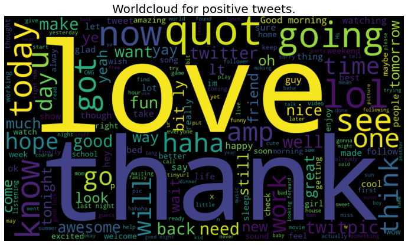

```python
plt.figure(figsize=(14,7))
word_cloud = WordCloud(stopwords = STOPWORDS, max_words = 200, width=1366, height=768, background_color="black").generate(" ".join(df[df.target==1].text))
plt.imshow(word_cloud,interpolation='bilinear')
plt.axis('off')
plt.title('Worldcloud for positive tweets.',fontsize=20)
plt.show()
```

[figure not shown]

```python
plt.figure(figsize=(14,7))
word_cloud = WordCloud(stopwords = STOPWORDS, max_words = 200, width=1366, height=768, background_color="black").generate(" ".join(df[df.target==0].text))
plt.imshow(word_cloud,interpolation='bilinear')
plt.axis('off')
plt.title('Worldcloud for positive tweets.',fontsize=20)
plt.show()
```

#### *We can depict that a few of the most repeated words are same in negative and positive classes: good,*

#### *But we can also depict positive class with words like: hope, thank, etc.*

#### *And we can also depict negative class with words like: hate, sad, etc.*

# 5. Data Preperation

[figure not shown]

```python
df1=df.copy() #for future usage
```

```python
df.drop(['ids','date','flag','username',], axis=1, inplace=True)
```

```python
df.head()
```

|  | target | text |
| --- | --- | --- |
| 0 | 0 | @switchfoot http://twitpic.com/2y1zl - Awww, t... |
| 1 | 0 | is upset that he can't update his Facebook by ... |
| 2 | 0 | @Kenichan I dived many times for the ball. Man... |
| 3 | 0 | my whole body feels itchy and like its on fire |
| 4 | 0 | @nationwideclass no, it's not behaving at all.... |

### Dealing with Stopwords

```python
stopwords_list = stopwords.words('english')
", ".join(stopwords.words('english'))
```

```
"i, me, my, myself, we, our, ours, ourselves, you, you're, you've, you'll, you'd, your, yours, yourself, yourselves, he, him, his, himself, she, she's, her, hers, herself, it, it's, its, itself, they, them, their, theirs, themselves, what, which, who, whom, this, that, that'll, these, those, am, is,…
```

```python
STOPWORDS = set(stopwords.words('english'))
def cleaning_stopwords(text):
    return " ".join([word for word in str(text).split() if word not in STOPWORDS])
df['text'] = df['text'].apply(lambda text: cleaning_stopwords(text))
```

### Dealing with usernames and urls

```python
def cleaning_all(text):
    text= re.sub('@\S+|https?:\S+|http?:\S|[^A-Za-z0-9]+', ' ', text)
    text = text.lower()
    text = text.split()
    return text
```

```python
df['text']= df['text'].apply(lambda x: cleaning_all(x))
```

```python
df.head()
```

|  | target | text |
| --- | --- | --- |
| 0 | 0 | [awww, that, s, bummer, you, shoulda, got, dav... |
| 1 | 0 | [upset, can, t, update, facebook, texting, it,... |
| 2 | 0 | [i, dived, many, times, ball, managed, save, 5... |
| 3 | 0 | [whole, body, feels, itchy, like, fire] |
| 4 | 0 | [no, behaving, all, i, m, mad, here, i, can, t... |

### Stemming

```python
stm = nltk.PorterStemmer()
def stemmer(t):
    text = [stm.stem(word) for word in t]
    return t
```

```python
df['text']= df['text'].apply(lambda x: stemmer(x))
```

```python
df.to_csv("df.csv")
```

```python
df['text'].head()
```

```
0    ['awww', 'that', 's', 'bummer', 'you', 'should...
1    ['upset', 'can', 't', 'update', 'facebook', 't...
2    ['i', 'dived', 'many', 'times', 'ball', 'manag...
3    ['whole', 'body', 'feels', 'itchy', 'like', 'f...
4    ['no', 'behaving', 'all', 'i', 'm', 'mad', 'he...
Name: text, dtype: object
```

### Lemmatizer

```python
lem = nltk.WordNetLemmatizer()
def lemmatizer(t):
    text = [lem.lemmatize(word) for word in t]
    return t
```

```python
df['text'] = df['text'].apply(lambda x: lemmatizer(x))
```

```python
import nltk
nltk.download('omw-1.4')
```

```
True
```

```python
df.head()
```

|  | target | text |
| --- | --- | --- |
| 0 | 0 | [awww, that, s, bummer, you, shoulda, got, david, carr, third, day, it, d] |
| 1 | 0 | [upset, can, t, update, facebook, texting, it, might, cry, result, school, today, also, blah] |
| 2 | 0 | [i, dived, many, times, ball, managed, save, 50, the, rest, go, bounds] |
| 3 | 0 | [whole, body, feels, itchy, like, fire] |
| 4 | 0 | [no, behaving, all, i, m, mad, here, i, can, t, see, there] |

# Task 6: Train and Test

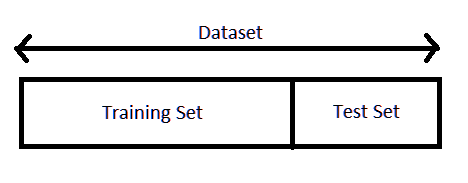

```python
df=pd.read_csv("/content/df")
```

```python
stopwords_list = stopwords.words('english')
", ".join(stopwords.words('english'))
```

```
"i, me, my, myself, we, our, ours, ourselves, you, you're, you've, you'll, you'd, your, yours, yourself, yourselves, he, him, his, himself, she, she's, her, hers, herself, it, it's, its, itself, they, them, their, theirs, themselves, what, which, who, whom, this, that, that'll, these, those, am, is,…
```

```python
X= df.text
Y = df.target
```

```python
X_train, X_test, Y_train, Y_test = train_test_split(X, Y, test_size=0.01, random_state=42)
```

### TF-IDF

```python
from sklearn.feature_extraction.text import TfidfVectorizer
```

```python
vectoriser = TfidfVectorizer(ngram_range=(1,2),stop_words = stopwords_list, strip_accents = 'unicode', max_features = 500000)
vectoriser.fit(X_train) #fit the training data
print(f'Vectorised.')
print('No. of feature_words: ', len(vectoriser.get_feature_names()))
```

```
Vectorised.
No. of feature_words:  500000
```

```python
X_train = vectoriser.transform(X_train)
X_test  = vectoriser.transform(X_test)
print(f'Transforming the dataset, done!')
```

```
Transforming the dataset, done!
```

# Task 7: Model Evaluation

```python
def evaluate(model, X_test,  Y_test):
    Y_pred = model.predict(X_test)
    print("Accuracy: ", accuracy_score(Y_test, Y_pred))
    print(classification_report(Y_test, Y_pred))
    print('Confusion Matrix:',ConfusionMatrixDisplay.from_predictions(Y_test,Y_pred))
```

## Logistic Regression

```python
from sklearn.linear_model import LogisticRegression
```

```
Accuracy:  0.79425
              precision    recall  f1-score   support

           0       0.81      0.77      0.79      7982
           1       0.78      0.81      0.80      8018

    accuracy                           0.79     16000
   macro avg       0.79      0.79      0.79     16000
weighted avg       0.79      0.79      0.79     16000

Confusion Matrix: <sklearn.metrics._plot.confusion_matrix.ConfusionMatrixDisplay object at 0x7f54764b3e50>
```

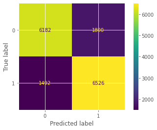

```python
model1 = LogisticRegression(random_state = 0)
model1.fit(X_train, Y_train)

evaluate(model1, X_test, Y_test)
```

## Bernoulli Naive Bayes

```
Accuracy:  0.7773125
              precision    recall  f1-score   support

           0       0.79      0.75      0.77      7982
           1       0.76      0.80      0.78      8018

    accuracy                           0.78     16000
   macro avg       0.78      0.78      0.78     16000
weighted avg       0.78      0.78      0.78     16000

Confusion Matrix: <sklearn.metrics._plot.confusion_matrix.ConfusionMatrixDisplay object at 0x7f1760eeedd0>
```

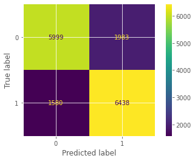

```python
from sklearn.naive_bayes import BernoulliNB
model2 = BernoulliNB(alpha = 2)
model2.fit(X_train, Y_train)
evaluate(model2, X_test, Y_test)
```

## SVM (linear)

```
Accuracy:  0.780875
              precision    recall  f1-score   support

           0       0.79      0.76      0.78      7982
           1       0.77      0.80      0.79      8018

    accuracy                           0.78     16000
   macro avg       0.78      0.78      0.78     16000
weighted avg       0.78      0.78      0.78     16000

Confusion Matrix: <sklearn.metrics._plot.confusion_matrix.ConfusionMatrixDisplay object at 0x7fe67943fc50>
```

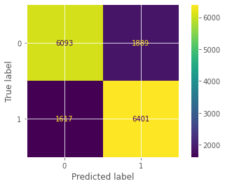

```python
from sklearn.svm import LinearSVC
model3 = LinearSVC()
model3.fit(X_train, Y_train)

evaluate(model3, X_test, Y_test)
```

## Decision Tree Classifier

```python
from sklearn.tree import DecisionTreeClassifier
model5 = DecisionTreeClassifier()
model5.fit(X_train, Y_train)

evaluate(model5, X_test, Y_test)
```

[output not shown]

## Random Forest Classifier

```python
from sklearn.ensemble import RandomForestClassifier
model6 = RandomForestClassifier(n_estimators = 200)
model6.fit(X_train, Y_train)

evaluate(model6, X_test, Y_test)
```

[output not shown]

## XGBoost

```
Accuracy:  0.67175
              precision    recall  f1-score   support

           0       0.79      0.46      0.59      7982
           1       0.62      0.88      0.73      8018

    accuracy                           0.67     16000
   macro avg       0.71      0.67      0.66     16000
weighted avg       0.71      0.67      0.66     16000

Confusion Matrix: <sklearn.metrics._plot.confusion_matrix.ConfusionMatrixDisplay object at 0x7f264877ed50>
```

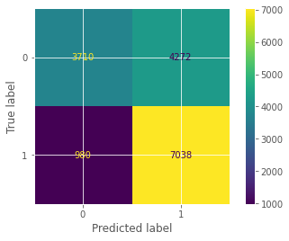

```python
from xgboost import XGBClassifier
model7 = XGBClassifier()
model7.fit(X_train, Y_train)

evaluate(model7, X_test, Y_test)
```

## AdaBoost

```
Accuracy:  0.6529375
              precision    recall  f1-score   support

           0       0.80      0.40      0.54      7982
           1       0.60      0.90      0.72      8018

    accuracy                           0.65     16000
   macro avg       0.70      0.65      0.63     16000
weighted avg       0.70      0.65      0.63     16000

Confusion Matrix: <sklearn.metrics._plot.confusion_matrix.ConfusionMatrixDisplay object at 0x7f264cae4e90>
```

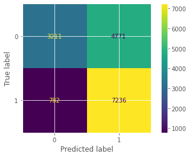

```python
from sklearn.ensemble import AdaBoostClassifier
model8 = AdaBoostClassifier()
model8.fit(X_train,Y_train)

evaluate(model8, X_test, Y_test)
```